# Lecture 7 - Fourier Series

## Joseph Fourier

Jean-Baptiste Joseph Fourier (21 March 1768 -- 16 May 1830) was a French mathematician and physicist born in Auxerre and best known for initiating the investigation of Fourier series and their applications to problems of heat transfer and vibrations. The Fourier transform and Fourier's law are also named in his honor. Fourier is also generally credited with the discovery of the greenhouse effect.

[figure not shown]

Theorie Analytique de la Chaleur was originally published in 1822. In this groundbreaking study, arguing that previous theories of mechanics advanced by such outstanding scientists as Archimedes, Galileo, Newton and their successors did not (adequately) explain the laws of heat, Fourier set out to study the mathematical laws governing heat diffusion and proposed that an infinite mathematical series may be used to analyse the conduction of heat in solids: this is now known as the 'Fourier Series'. His work paved the way for modern mathematical physics. This book will be especially useful for mathematicians who are interested in trigonometric series and their applications, and it is reissued simultaneously with Alexander Freeman's English translation, The Analytical Theory of Heat, of 1878.

[figure not shown]

Heat distribution in a plate owing to a heat source placed near the top right corner.

## Introduction to Fourier Series

We have already encountered Taylor series which provide a mechanism for representing continuous and infinitely differentiable functions as an infinite sum of polynomial terms. Fourier Series provide a mechanism for representing **periodic** functions as an infinite sum. Although Fourier Series are restricted to periodic functions, they have the advantage that they are applicable to functions which are not infinitely differentiable, even to some functions which are not continuous.

The simplest periodic functions we can think of are probably $\cos$ and $\sin$ so it is of little surprise that a Fourier Series represents functions as a sum of $\sin$ and $\cos$ functions. In particular, if $f(x)$ is a function with period $2\pi$ then the Fourier Series representation of $f(x)$ is:

\begin{equation*} f(x)=\frac{a_0}{2}+\sum_{n=1}^{\infty}a_n\cos nx+\sum_{n=1}^{\infty}b_n\sin nx \end{equation*}

for some set of coefficients $a_n$ and $b_n$. The functions $\cos nx$ and $\sin nx$ are termed **basis** functions. Before we move on to derive the values of these coefficients, it is useful to look at some particular properties of $\sin nx$ and $\cos nx$.

Note: Sometimes you will the the Fourier series of some function $f(x)$ written as $F_{f(x)}$ (or similar).

## Orthogonality of $\sin$ and $\cos$ functions

What do we have if we integrate the basis functions over the length of the period of the function? In the following cases we will integrate over the interval $[-\pi,\pi]$ but note that any interval of length $2\pi$ will produce the same result.

We have:

\begin{equation*} \int_{-\pi}^{\pi} \cos nx \mathrm{d}x = \begin{cases} 0 & (n\ne 0)\\ 2\pi & (n= 0) \end{cases} \end{equation*}

and:

\begin{equation*} \int_{-\pi}^{\pi} \sin nx \mathrm{d}x = 0 \quad (\textrm{for all } n) \end{equation*}

What about the product of two basis functions? For $n,m\geq0$ we have:

\begin{equation*} \int_{-\pi}^{\pi} \cos nx \cos mx \mathrm{d}x = \int_{-\pi}^{\pi}\frac{1}{2} \cos (n+m)x\mathrm{d}x + \int_{-\pi}^{\pi}\frac{1}{2} \cos (n-m)x \mathrm{d}x \end{equation*}

For the first of these terms we already know:

\begin{equation*} \int_{-\pi}^{\pi}\frac{1}{2} \cos (n+m)x\mathrm{d}x = \begin{cases} \pi & n=m=0\\ 0 & \textrm{otherwise} \end{cases} \end{equation*}

while for the second one we know:

\begin{equation*} \int_{-\pi}^{\pi}\frac{1}{2} \cos (n-m)x\mathrm{d}x = \begin{cases} \pi & n=m\\ 0 & \textrm{otherwise} \end{cases} \end{equation*}

This results in:

\begin{equation*} \int_{-\pi}^{\pi} \cos nx \cos mx \mathrm{d}x = \begin{cases} 2\pi & n=m=0\\ \pi & n=m\ne 0\\ 0 & n\neq m \end{cases} \end{equation*}

Similarly, we can write:

\begin{equation*} \int_{-\pi}^{\pi} \sin nx \sin mx \mathrm{d}x = -\int_{-\pi}^{\pi}\frac{1}{2} \cos (n+m)x\mathrm{d}x + \int_{-\pi}^{\pi}\frac{1}{2} \cos (n-m)x \mathrm{d}x \end{equation*}

With the result that:

\begin{equation*} \int_{-\pi}^{\pi} \sin nx \sin mx \mathrm{d}x = \begin{cases} 0 & n=m=0\\ \pi & n=m\ne 0\\ 0 & n\neq m \end{cases} \end{equation*}

The first of these cases should not be a surprise since $\sin 0x=0$. The final combination occurs if we multiply $\sin$ by $\cos$:

\begin{align*} \int_{-\pi}^{\pi} \sin nx \cos mx \mathrm{d}x &= \int_{-\pi}^{\pi}\frac{1}{2} \sin (n+m)x\mathrm{d}x + \int_{-\pi}^{\pi}\frac{1}{2} \sin (n-m)x \mathrm{d}x\\ &=0 \end{align*}

With these integrals we have discovered a very important property of our set of basis functions:

\begin{equation*} {1, \cos x, \cos 2x, \ldots, \sin x, \sin 2x, \ldots} \end{equation*}

This property is that functions in this set are \emph{orthogonal}. That is to say, if we have basis functions $f(x)$ and $g(x)$ from this set then:

\begin{equation*} \int_{-\pi}^{\pi}f(x)g(x)\mathrm{d}x\neq0 \Leftrightarrow f(x)=g(x) \end{equation*}

## Fourier coefficients

The orthogonality property above enables us to determine the coefficients of the Fourier Series. Recall that the series is written:

\begin{equation*} f(x)=\frac{a_0}{2}+\sum_{n=1}^{\infty}a_n\cos nx+\sum_{n=1}^{\infty}b_n\sin nx \end{equation*}

If we integrate the series over the period interval $[-\pi,\pi]$ then we have:

\begin{align*} \int_{-\pi}^{\pi}f(x)\mathrm{d}x&=\int_{-\pi}^{\pi}\frac{a_0}{2}\mathrm{d}x +\sum_{n=1}^{\infty}\underbrace{\int_{-\pi}^{\pi}a_n\cos nx\mathrm{d}x}_{=0} +\sum_{n=1}^{\infty}\underbrace{\int_{-\pi}^{\pi}b_n\sin nx\mathrm{d}x}_{=0}\\ &=\pi a_0 \end{align*}

so that: \begin{equation} a_0=\frac{1}{\pi}\int_{-\pi}^{\pi}f(x)\mathrm{d}x \end{equation}

From this we can see the role of the $a_0/2$ term in the series: it is the mean of the function over the period. To obtain the other coefficients we must use the orthogonality condition in a slightly more sophisticated way. First, we multiply by $\cos mx$ for some positive integer $m$ and integrate over the usual period:

\begin{align*} \int_{-\pi}^{\pi}f(x)\cos mx\mathrm{d}x=\frac{a_0}{2}\int_{-\pi}^{\pi}\cos mx\mathrm{d}x &+\sum_{n=1}^{\infty}a_n\int_{-\pi}^{\pi}\cos nx\cos mx\mathrm{d}x\\ &+\sum_{n=1}^{\infty}b_n\int_{-\pi}^{\pi}\sin nx\cos mx\mathrm{d}x \end{align*}

From the orthogonality properties, we know that all of the terms on the right-hand side are zero except for $a_n\int_{-\pi}^{\pi}\cos nx\cos mx\mathrm{d}x$ in the case where $n=m$. That is:

\begin{align*} \int_{-\pi}^{\pi}f(x)\cos mx\mathrm{d}x&=a_m\int_{-\pi}^{\pi}\cos mx\cos mx\mathrm{d}x\\ &=\pi a_m \end{align*}

Or to write it around the other way and use $n$ instead of $m$:

\begin{equation} a_n=\frac{1}{\pi}\int_{-\pi}^{\pi}f(x)\cos nx\mathrm{d}x \quad n=1,2,\ldots \end{equation}

This makes it clear that the definition of $a_n$ is the same for $n=0$ as for positive $n$. Maintaining this consistency is the reason that the factor $1/2$ is included in the $a_0$ term of the Fourier series. To recover the values of the $b_n$ coefficients, we multiply by $\sin mx$:

\begin{align*} \int_{-\pi}^{\pi}f(x)\sin mx\mathrm{d}x=\frac{a_0}{2}\int_{-\pi}^{\pi}\sin mx\mathrm{d}x &+\sum_{n=1}^{\infty}a_n\int_{-\pi}^{\pi}\cos nx\sin mx\mathrm{d}x\\ &+\sum_{n=1}^{\infty}b_n\int_{-\pi}^{\pi}\sin nx\sin mx\mathrm{d}x \end{align*}

This time all of the right hand side terms are zero but for the $b_n\int_{-\pi}^{\pi}\sin nx\sin mx\mathrm{d}x$ term for $n=m$. So that:

\begin{equation} b_n=\frac{1}{\pi}\int_{-\pi}^{\pi}f(x)\sin nx\mathrm{d}x \quad n=1,2,\ldots \end{equation}

In this course we will primarily focus on obtaining Fourier series for given functions: we will use the equations for $a_0$, $a_n$ and $b_n$ to obtain Fourier series expansion.

## Fourier series example: square wave

Let's take as an example function with period $2\pi$:

\begin{equation} f(x)= \begin{cases} -k &(2m-1) \pi<x<2m \pi\\ k &2m \pi<x<(2m+1) \pi \end{cases}\quad m=\ldots,-2,1,0,1,2,\ldots \end{equation}

This function is piecewise constant and discontinuous at values of $x$ corresponding to integer multiples of $\pi$. Let's try to establish its Fourier series, starting with equation $a_0$:

\begin{align*} a_0&=\frac{1}{\pi}\int_{-\pi}^{\pi} f(x)\mathrm{d}x\\ &=\frac{1}{\pi}\int_{-\pi}^0 -k \mathrm{d}x+ \frac{1}{\pi}\int_0^{\pi} k \mathrm{d}x\\ &=-k+k\\ &=0 \end{align*}

This is the result we expect as the mean value of this function is clearly $0$.

The cosine coefficients $a_n$ are now obtained:

\begin{align*} a_n&=\frac{1}{\pi}\int_{-\pi}^{\pi} f(x)\cos nx\mathrm{d}x\\ &=-\frac{k}{\pi}\int_{-\pi}^0\cos nx\mathrm{d}x + \frac{k}{\pi}\int_0^{\pi}\cos nx\mathrm{d}x\\ &=-\frac{k}{\pi}\left.\frac{\sin nx}{n}\right|_{-\pi}^0 +\frac{k}{\pi}\left.\frac{\sin nx}{n}\right|_0^{\pi}\\ &=-\frac{k}{\pi}(0-0)+\frac{k}{\pi}(0-0)\\ &=0 \end{align*}

Finally, we can obtain the sine coefficients $b_n$:

\begin{align*} b_n&=\frac{1}{\pi}\int_{-\pi}^{\pi} f(x)\sin nx\mathrm{d}x\\ &=-\frac{k}{\pi}\int_{-\pi}^0\sin nx\mathrm{d}x + \frac{k}{\pi}\int_0^{\pi}\sin nx\mathrm{d}x\\ &=+\frac{k}{\pi}\left.\frac{\cos nx}{n}\right|_{-\pi}^0 -\frac{k}{\pi}\left.\frac{\cos nx}{n}\right|_0^{\pi}\\ &=\frac{k}{n\pi}(1-\cos n\pi -\cos n\pi+1)\\ &=\frac{2k}{n\pi}(1-\cos n\pi)\\ &=\frac{2k}{n\pi}(1-(-1)^n) \end{align*}

So:

\begin{equation*} b_n= \begin{cases} \displaystyle\frac{4k}{n\pi} & n \textrm{ odd}\\ 0 & n \textrm{ even} \end{cases} n = 1,2,3,\ldots \end{equation*}

So, $a_0$ and the cosine terms are all zero, while the sine term are non-zero for odd values of $n$. Noting that $(2n-1)$ produces the required sequence of odd non--zero numbers, when $n = 1,2,3,\ldots$, we can write the final Fourier series representation as:

\begin{align*} f(x)&=\frac{4k}{\pi}\sum_{n=1}^\infty \frac{\sin \left( (2n-1) x \right) }{(2n-1)}\\ &=\frac{4k}{\pi}\left(\sin x+\frac{\sin 3x}{3}+\frac{\sin 5x}{5}+\ldots\right) \end{align*}

Let plot this for a few truncation orders:

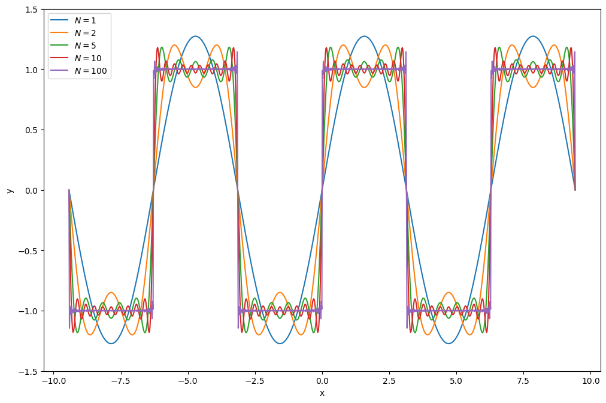

```python
%matplotlib inline
import numpy as np
import matplotlib.pyplot as plt

N = 1000
x = np.linspace(-3*np.pi,3*np.pi,N)

def eval_f(x,N):
    f = 0
    for i in range(1,N+1):
        f += np.sin((2*i-1)*x)/(2*i-1)
    return 4/np.pi*f

y1 = eval_f(x,1)
y2 = eval_f(x,2)
y3 = eval_f(x,5)
y4 = eval_f(x,10)
y5 = eval_f(x,100)

fig=plt.figure(figsize=(12,8), dpi= 100, facecolor='w', edgecolor='k')
plt.plot(x, y1, label = "$N=1$")
plt.plot(x, y2, label = "$N=2$")
plt.plot(x, y3, label = "$N=5$")
plt.plot(x, y4, label = "$N=10$")
plt.plot(x, y5, label = "$N=100$")
plt.xlabel("x")
plt.ylabel("y")
plt.ylim((-1.5,1.5))
plt.legend()
plt.show()
```

Note that the actual analytical function is discontinuous.

As expected, if we add more terms, the representation improves, although there are always some wiggles where the series struggles to represent the discontinuity. This is known as the **Gibbs phenomenon**.

## Fourier series of odd and even functions

We might next turn our thoughts to the peculiar nature of the Fourier series we have derived for the preceding function. That $a_0$ is zero is easily explained as the mean of this function is zero. Why, though are all of the other $a_n$ also zero?

To answer this we must consider two important classes of function:

- **Even** functions are those for which \begin{equation*} f(x)=f(-x) \end{equation*} That is, even functions are symmetric about the $y$ axis. $\cos x$ is a classical example of an even function.
- **Odd** functions are those for which \begin{equation*} f(-x)=-f(x) \end{equation*} Odd functions are rotationally symmetric about the origin. $\sin x$ is a typical odd function.

Note that it is quite possible for a function to be neither even nor odd, $e^x$ being a good example of such a function. Multiplying odd and even functions has the same implications for odd and evenness as multiplying negative and positive numbers:

- The product of two **even** functions $f$ and $g$, is an **even** function: \begin{equation*} f(-x) \cdot g(-x) = f(x) \cdot g(x) \end{equation*}
- The product of two **odd** functions $f$ and $g$, is an **even** function: \begin{equation*} f(-x) \cdot g(-x) = - f(x) \cdot - g(x) = f(x) \cdot g(x) \end{equation*}
- The product of an **odd** function $f$ with an **even** function $g$, is an **odd** function: \begin{equation*} f(-x) \cdot g(-x) = - f(x) \cdot g(x) \end{equation*}

From the perspective of Fourier series, odd and even functions have particular properties when integrated **on an interval symmetric about zero**:

- If $f$ is **even** then: \begin{equation*} \int_0^{\pi}f(x)\mathrm{d}x = \int_{-\pi}^{0}f(x)\mathrm{d}x \end{equation*} with the result that: \begin{equation*} \int_{-\pi}^{\pi} f(x)\mathrm{d}x = 2\int_0^{\pi}f(x)\mathrm{d}x \end{equation*} Which in general is non-zero.
- If $f$ is **odd** then: \begin{equation*} \int_0^{\pi}f(x)\mathrm{d}x = -\int_{-\pi}^{0}f(x)\mathrm{d}x \end{equation*} with the result that: \begin{equation*} \int_{-\pi}^{\pi} f(x)\mathrm{d}x = 0 \end{equation*}

In Fourier series basis functions, $\sin nx$ is odd for any $n$ while $\cos nx$ is always even. The function which we looked at in the last example is clearly **odd**. So, $f(x)\sin nx$ is even for any $n$ while $f(x)\cos nx$ is odd for any $n$. Therefore,

\begin{equation*} \int_{-pi}^{\pi} f(x)\cos nx\mathrm{d}x=0 \end{equation*}

with the result that $a_n=0$ for all $n\geq0$. By contrast, $\int_{-\pi}^{\pi} f(x)\sin nx\mathrm{d}x$ may be non-zero with the result that some (half in this case) of the $b_n$ are non-zero, and the Fourier series expansion is composed entirely of sine terms. In contrast, if the function under consideration is even, then all of the $b_n$ will be zero and the Fourier series will consist entirely of cosine terms.

## Fourier series example: piecewise polynomial

Let's now consider a slightly more complex function. Let $f$ be the function with period $2\pi$ defined on the interval $[-\pi,\pi]$ by:

\begin{equation*} f(x)=x^2 \end{equation*}

This function is shown below:

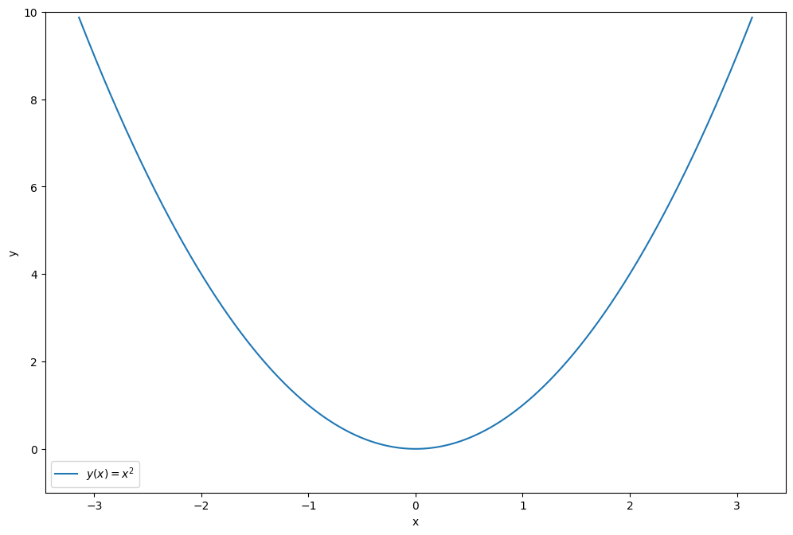

```python
%matplotlib inline
import numpy as np
import matplotlib.pyplot as plt

N = 1000
x = np.linspace(-np.pi,np.pi,N)

fig=plt.figure(figsize=(12,8), dpi= 100, facecolor='w', edgecolor='k')
plt.plot(x, x**2, label = "$y(x)=x^2$")
plt.xlabel("x")
plt.ylabel("y")
plt.ylim((-1,10))
plt.legend()
plt.show()
```

Ok, lets form our Fourier expansion.

First, we observe that the function is even within the interval of integration $[-\pi, \pi]$:

\begin{equation*} f(-x) = (-x)^2 = x^2 = f(x) \end{equation*}

Hence we know in advance that $b_n=0$ for all $n$.

We expect $a_0$ to be non--zero, as the function is positive inside the interval of integration:

\begin{align*} a_0&=\frac{1}{\pi}\int_{-\pi}^{\pi} f(x)\mathrm{d}x \\ &=\frac{1}{\pi}\int_{-\pi}^{\pi} x^2\mathrm{d}x \\ &=\frac{1}{\pi}\left.\frac{x^3}{3}\right|_{-\pi}^{\pi}\\ &=\frac{1}{\pi}\left(\frac{\pi^3}{3}--\frac{\pi^2}{3}\right)\\ &=\frac{2\pi^2}{3} \end{align*}

For $a_n$ we have:

\begin{align*} a_n&=\frac{1}{\pi}\int_{-\pi}^{\pi} f(x)\cos nx \mathrm{d}x\\ &=\frac{1}{\pi}\int_{-\pi}^{\pi} x^2\cos nx \mathrm{d}x \end{align*}

To evaluate this integral we will need to employ integration by parts. We define:

\begin{equation*} u=x^2\qquad v'=\cos nx \end{equation*}

so that:

\begin{equation*} u'=2x\qquad v=\frac{\sin nx}{n} \end{equation*}

Recall the integration by parts formula:

\begin{equation*} \int_a^b uv'\mathrm{d}x = \left.-\int_a^b u'v\mathrm{d}x + uv\right|_a^b \end{equation*}

Hence:

\begin{align*} a_n&=-\frac{2}{n\pi}\int_{-\pi}^{\pi} x\sin nx \mathrm{d}x + \left.\frac{1}{n\pi}x^2\sin nx\right|_{-\pi}^{\pi}\\ &=-\frac{2}{n\pi}\int_{-\pi}^{\pi} x\sin nx \mathrm{d}x +0 \end{align*}

We need to apply integration by parts again. This time:

\begin{equation*} u=x\qquad v'=\sin nx \end{equation*}

and therefore:

\begin{equation*} u'=1\qquad v=-\frac{\cos nx}{n} \end{equation*}

So:

\begin{align*} a_n&=-\frac{2}{n^2\pi}\int_{-\pi}^{\pi}\cos nx \mathrm{d}x + \left.\frac{2}{n^2\pi}x\cos nx\right|_{-\pi}^{\pi}\\ &=\left.-\frac{2}{n^3\pi} \sin nx \right|_{-\pi}^{\pi} + \left.\frac{2}{n^2\pi}x\cos nx\right|_{-\pi}^{\pi}\\ &=0+\frac{2}{n^2\pi}\left(\pi\cos n\pi--\pi \cos -n\pi\right)\\ &=\frac{2}{n^2}(2\cos n\pi)\\ &=\frac{4(-1)^n}{n^2} \end{align*}

So the full Fourier series is:

\begin{align*} f(x) &= \frac{a_0}{2}+\sum_{n=1}^{\infty}a_n\cos nx+\sum_{n=1}^{\infty}b_n\sin nx \\ &= \frac{\pi^2}{3}+4\sum_{n=1}^{\infty}(-1)^n\frac{\cos nx}{n^2} \qquad |x|<\pi \end{align*}

The function is extended periodically to all other x by subtracting the appropriate multiple of $2\pi$. Once again, it is instructive to plot a few terms of the series:

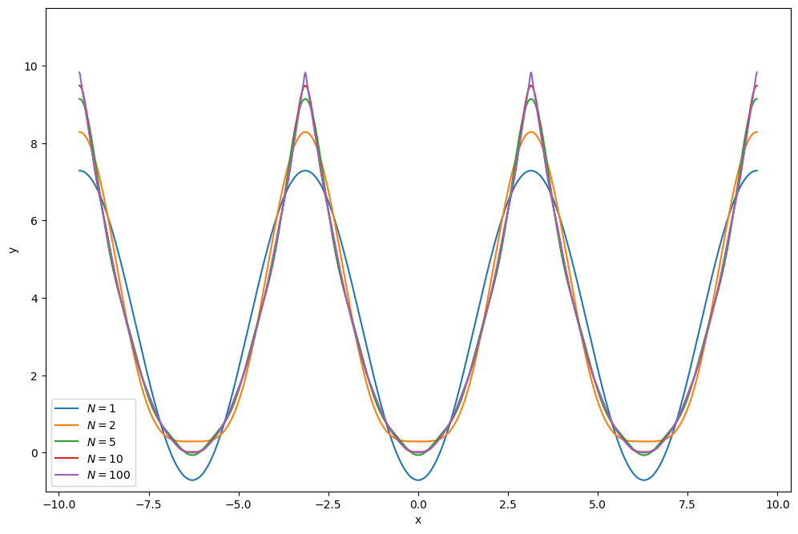

```python
%matplotlib inline
import numpy as np
import matplotlib.pyplot as plt

N = 1000
x = np.linspace(-3*np.pi,3*np.pi,N)

def eval_fc(x,N):
    f = np.pi**2/3
    for i in range(1,N+1):
        f += 4*(-1)**i/i**2*np.cos(i*x)
    return f

y1 = eval_fc(x,1)
y2 = eval_fc(x,2)
y3 = eval_fc(x,5)
y4 = eval_fc(x,10)
y5 = eval_fc(x,100)

fig=plt.figure(figsize=(12,8), dpi= 100, facecolor='w', edgecolor='k')
plt.plot(x, y1, label = "$N=1$")
plt.plot(x, y2, label = "$N=2$")
plt.plot(x, y3, label = "$N=5$")
plt.plot(x, y4, label = "$N=10$")
plt.plot(x, y5, label = "$N=100$")
plt.xlabel("x")
plt.ylabel("y")
plt.ylim((-1.0,11.5))
plt.legend()
plt.show()
```

Let's see what we get when we substitute $x = \pi$ in the Fourier series that we have just developed.

\begin{align*} \pi^2 = \frac{\pi^2}{3}+4\sum_{n=1}^{\infty}(-1)^n\frac{\cos n \pi}{n^2} \qquad |x|<\pi \end{align*}\begin{align*} \frac{\pi^2}{6} = \sum_{n=1}^{\infty}(-1)^n\frac{(-1)^n}{n^2} \end{align*}\begin{align*} \frac{\pi^2}{6} = \sum_{n=1}^{\infty}\frac{1}{n^2} = 1 + \frac{1}{2^2} + \frac{1}{3^2} + ... \end{align*}

Hence we have found the sum of $1/n^2$ series.

## Change of interval

If the function $f(x)$ under consideration has a period $p=2L$ then we can construct a Fourier series by changing variable, effectively we change the scale on the x axis. The appropriate scale would be:

\begin{equation*} u=\frac{\pi x}{L} \end{equation*}

We can construct a new function $g(u)=f(x)$ simply by substituting this change of coordinates into $f$ and then write the Fourier series for $g$:

\begin{equation*} g(u)=\frac{a_0}{2}+\sum_{n=1}^{\infty} a_n\cos nu +\sum_{n=1}^{\infty} b_n\sin nu \end{equation*}

using the change of coordinates, we have:

\begin{equation*} f(x)=\frac{a_0}{2}+\sum_{n=1}^{\infty} a_n\cos \frac{n\pi}{L}x +\sum_{n=1}^{\infty} b_n\sin\frac{n\pi}{L}x \end{equation*}

Note that:

\begin{align*} \frac{\mathrm{d}u}{\mathrm{d}x}=\frac{\pi}{L} \end{align*}

So that:

\begin{align*} a_0&=\frac{1}{\pi}\int_{-\pi}^{\pi}g(u)\mathrm{d} u\\ &=\frac{1}{\pi}\int_{-L}^L\frac{\pi}{L}f(x)\mathrm{d} x\\ &=\frac{1}{L}\int_{-L}^L f(x)\mathrm{d} x \end{align*}

Similarly:

\begin{align*} a_n&=\frac{1}{\pi}\int_{-\pi}^{\pi}g(u)\cos(nu)\mathrm{d} u\\ &=\frac{1}{\pi}\int_{-L}^Lf(x)\cos\left(\frac{n\pi x}{L}\right)\frac{\pi}{L}\mathrm{d} x\\ &=\frac{1}{L}\int_{-L}^Lf(x)\cos\left(\frac{n\pi x}{L}\right)\mathrm{d} x\\ \end{align*}

And:

\begin{align*} b_n&=\frac{1}{\pi}\int_{-\pi}^{\pi}g(u)\sin(nu)\mathrm{d} u\\ &=\frac{1}{\pi}\int_{-L}^Lf(x)\sin\left(\frac{n\pi x}{L}\right)\frac{\pi}{L}\mathrm{d} x\\ &=\frac{1}{L}\int_{-L}^Lf(x)\sin\left(\frac{n\pi x}{L}\right)\mathrm{d} x\\ \end{align*}

### Example

Compute the Fourier series of the following periodic function:

\begin{equation*} f(x)= \begin{cases} -x& -1<x<0& \\ x& 0\leq x \leq 1.& \end{cases} \end{equation*}

The width of the domain is 2 and hence $2L=2 \rightarrow L=1$. Applying the equations above we have

\begin{equation*} a_0=\frac{1}{L}\int_{-L}^L f(x)\mathrm{d} x=\int_{-1}^1 f(x)\mathrm{d} x=\int_{-1}^{0}-x\mathrm{d}x +\int_{0}^{1}x\mathrm{d}x=1. \end{equation*}

Note, since $a_0/2$ represents the average of the function over a period windows, it's easy to see in this case that it's average is indeed a half.

Next, we have

\begin{align*} a_n&=\frac{1}{L}\int_{-L}^Lf(x)\cos\left(\frac{n\pi x}{L}\right)\mathrm{d}x=\int_{-1}^{0}-x\cos(n\pi x)\mathrm{d}x+\int_{0}^{1}x\cos(n\pi x)\mathrm{d}x \\ &=2\int_{0}^{1}x\cos(n\pi x)\mathrm{d}x \\ &=2\left(\left[\frac{x\sin(n\pi x)}{n\pi}\right]_{0}^{1}-\int_{0}^{1}\frac{\sin(n\pi x)}{n\pi}\mathrm{d}x\right) \\ &=2\left(0+\left.\frac{\cos(n\pi x)}{n^2\pi^2}\right|_{0}^{1}\right) \\ &=\frac{2}{(n\pi)^2}\left[(-1)^n-1\right]. \end{align*}

Therefore, $a_n=0$ for even $n$. Since this is an even function, $b_n=0$ for all $n$. Hence, our Fourier series takes the form

\begin{equation*} f(x)=\frac{1}{2}+\sum_{1}^{\infty}\frac{-4}{(2n-1)^2\pi^2}\cos((2n-1)\pi x), \end{equation*}

or, equivalently,

\begin{equation*} f(x)=\frac{1}{2}-4\sum_{0}^{\infty}\frac{1}{(2n+1)^2\pi^2}\cos((2n+1)\pi x). \end{equation*}

Lets check we're correct by plotting our series!

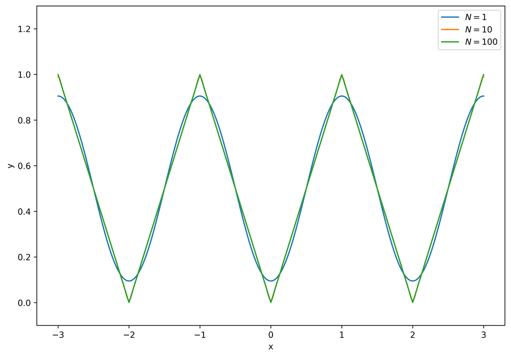

```python
%matplotlib inline
import numpy as np
import matplotlib.pyplot as plt

xp = 2001
x = np.linspace(-3,3,xp)

def eval_fc(x,N):
    f = 0.5
    s = 0.0
    for i in range(1,N+1):
        s += 1/(2*i-1)**2*np.cos((2*i-1)*np.pi*x)
    return f-4*s/np.pi**2

y1 = eval_fc(x,1)
y2 = eval_fc(x,10)
y3 = eval_fc(x,100)

fig=plt.figure(figsize=(10,7), dpi= 600, facecolor='w', edgecolor='k')
plt.plot(x, y1, label = "$N=1$")
plt.plot(x, y2, label = "$N=10$")
plt.plot(x, y3, label = "$N=100$")
plt.xlabel("x")
plt.ylabel("y")
plt.ylim((-0.1,1.3))
plt.legend()
plt.show()
```